# 02_Luis_Kelly_2018

Kelly Luis

9/15/2018

## 1. R Warmup

**1a.** Create a vector of 100 randomly distributed numbers between 0 and 100 using `runif` and save the vector into the variable `my_vec`. If you cannot figure out runif, try `?runif`. What information does `str` and `summary` tell you about `my_vec`? How do they differ?

```r
my_vec <- runif(100, min =0, max = 100)
str(my_vec)
```

```
##  num [1:100] 79 22.8 53.5 56.7 12.2 ...
```

```r
summary(my_vec)
```

```
##    Min. 1st Qu.  Median    Mean 3rd Qu.    Max.
##  0.6844 30.0055 54.0360 52.1005 74.9369 99.8205
```

str(my_vec) displays the class type (num), size (1:00), and the first few items of items of my_vec

summary(my_vec) displays the minimum, 1st quartile, median, mean, 3rd quartile, and maximum of my_vec

**1b**. Try out a little plot. What does `hist(my_vec)` show you? What information does the helpfile for `hist` tell you about what you just did?

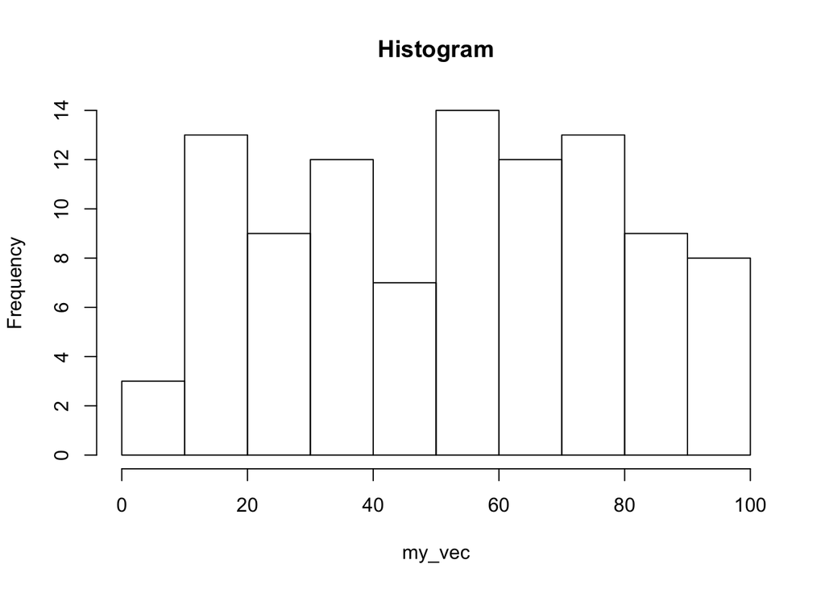

```r
hist(my_vec, main = "Histogram")
```

hist(my_vec) displays the histogram of the my_vec where the frequency of items are displayed by bin size

**1c.** Load up the `mtcars` data set using `data(mtcars)`. Apply the following functions to mtcars: `class`, `str`, `summary`. What do these three functions tell you about mtcars?

```r
data(mtcars)
class(mtcars)
```

```
## [1] "data.frame"
```

```r
str(mtcars)
```

```
## 'data.frame':    32 obs. of  11 variables:
##  $ mpg : num  21 21 22.8 21.4 18.7 18.1 14.3 24.4 22.8 19.2 ...
##  $ cyl : num  6 6 4 6 8 6 8 4 4 6 ...
##  $ disp: num  160 160 108 258 360 ...
##  $ hp  : num  110 110 93 110 175 105 245 62 95 123 ...
##  $ drat: num  3.9 3.9 3.85 3.08 3.15 2.76 3.21 3.69 3.92 3.92 ...
##  $ wt  : num  2.62 2.88 2.32 3.21 3.44 ...
##  $ qsec: num  16.5 17 18.6 19.4 17 ...
##  $ vs  : num  0 0 1 1 0 1 0 1 1 1 ...
##  $ am  : num  1 1 1 0 0 0 0 0 0 0 ...
##  $ gear: num  4 4 4 3 3 3 3 4 4 4 ...
##  $ carb: num  4 4 1 1 2 1 4 2 2 4 ...
```

```r
summary(mtcars)
```

```
##       mpg             cyl             disp             hp
##  Min.   :10.40   Min.   :4.000   Min.   : 71.1   Min.   : 52.0
##  1st Qu.:15.43   1st Qu.:4.000   1st Qu.:120.8   1st Qu.: 96.5
##  Median :19.20   Median :6.000   Median :196.3   Median :123.0
##  Mean   :20.09   Mean   :6.188   Mean   :230.7   Mean   :146.7
##  3rd Qu.:22.80   3rd Qu.:8.000   3rd Qu.:326.0   3rd Qu.:180.0
##  Max.   :33.90   Max.   :8.000   Max.   :472.0   Max.   :335.0
##       drat             wt             qsec             vs
##  Min.   :2.760   Min.   :1.513   Min.   :14.50   Min.   :0.0000
##  1st Qu.:3.080   1st Qu.:2.581   1st Qu.:16.89   1st Qu.:0.0000
##  Median :3.695   Median :3.325   Median :17.71   Median :0.0000
##  Mean   :3.597   Mean   :3.217   Mean   :17.85   Mean   :0.4375
##  3rd Qu.:3.920   3rd Qu.:3.610   3rd Qu.:18.90   3rd Qu.:1.0000
##  Max.   :4.930   Max.   :5.424   Max.   :22.90   Max.   :1.0000
##        am              gear            carb
##  Min.   :0.0000   Min.   :3.000   Min.   :1.000
##  1st Qu.:0.0000   1st Qu.:3.000   1st Qu.:2.000
##  Median :0.0000   Median :4.000   Median :2.000
##  Mean   :0.4062   Mean   :3.688   Mean   :2.812
##  3rd Qu.:1.0000   3rd Qu.:4.000   3rd Qu.:4.000
##  Max.   :1.0000   Max.   :5.000   Max.   :8.000
```

1. class(mtcars) tells you that mtcars is a data frame
2. str(mtcars) tells you that there are 32 observations of 11 variables, where each variable is numeric
3. summary(mtcars) tells you the summary statistics (or more plainly, the spread of the data) for each of the 11 variables

**1d** Look at the help file for the class `data.frame`. What does it tell you about these objects?

The data.frame class is a list of variables with the same number of rows with unique row names.

## 2. Sample Properties

Consider the following vasopressin levels in voles.

```r
vole_vaso <- c(98,96,94,88,86,82,77,74,70,60,
           59,52,50,47,40,35,29,13,6,5)
```

**2a.** Say “Vole vasopressin” 10 times as fast as you can. How many times did you trip up?

**4**

**2b.** What is the mean, median, sd, and interquartile range of the sample?

```r
vole_mean <- mean(vole_vaso)
vole_median <- median(vole_vaso)
vole_sd <- sd(vole_vaso)
vole_iqr <- IQR(vole_vaso)
```

**2c**. What is the standard error of the mean (do this with a formula!)?

```r
vole_se <- vole_sd/sqrt(length(vole_vaso))
```

**2d.** What does the standard error of the mean tell you about our estimate of the mean values of the population of vole vassopressin? The standard error of the mean tells you the variaiblity of the mean if you were to sample a bunch of times, which in this case is 6.6528486.

## 3. Sample Size for upper quartiles.

We can get the upper quartile value of vole vassopressin with

```r
quantile(vole_vaso, probs = 0.75)
```

```
## 75%
##  83
```

Let’s assume the sample is representative of the popultion.

**3a**. Use `sample()` to get just one resample with a sample size of 10. What is its upper quartile?

```r
uq_resample <- quantile(sample(vole_vaso, size = 10), probs = 0.75)
```

**3b.** Build an initial data frame for simulations with the sample sizes 5 through 20. Have 100 simulations per sample size.

```r
vole_sim <- data.frame(samp_size3 = rep(5:20, 100)) %>%
  mutate(sims = 1:n())
```

**3c.** Use this data frame to get simulated upper quartiles for each sample size.

```r
vole_sim <- vole_sim %>%
  rowwise() %>%
  mutate(uq = quantile(sample(vole_vaso, samp_size3, replace=T), probs=0.75)) %>%
  ungroup()
```

**3d.** With a plot, make a guesstimate as to the best sample size for estimating the upper quartile of the population.

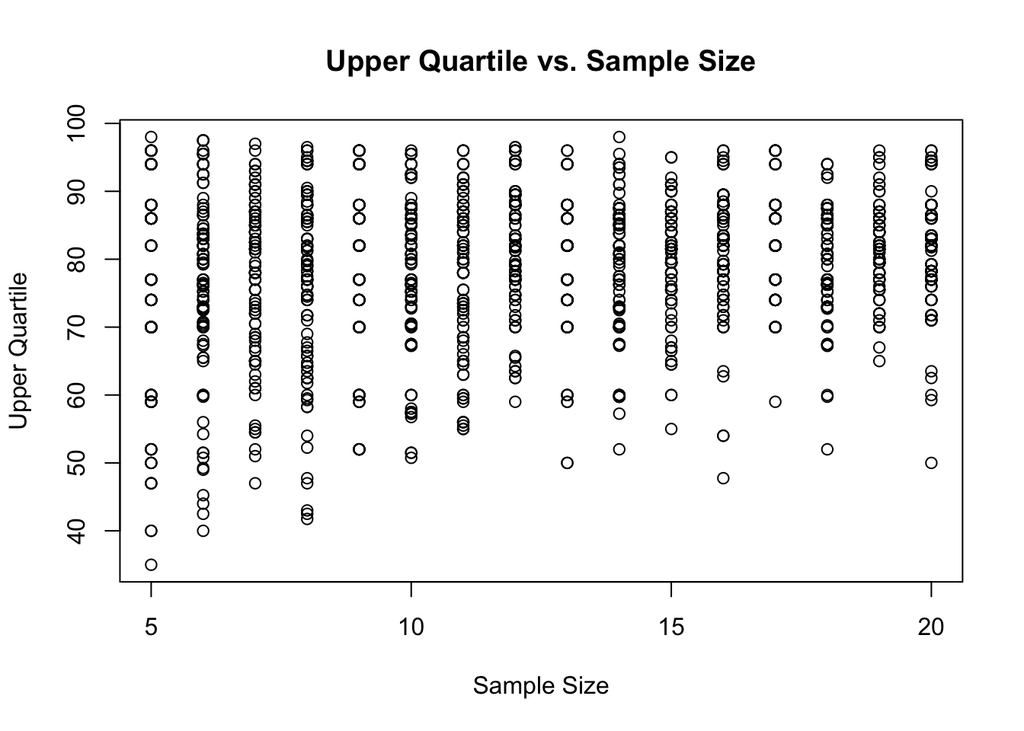

```r
plot(uq ~ samp_size3, data=vole_sim, main = "Upper Quartile vs. Sample Size", xlab = "Sample Size", ylab = "Upper Quartile")
```

We can guesstimate the best sample size by determining where the variaiblity levels off, which by eye looks like any sample size greater than 15.

## 4. SE and CI

**4a.** With the upper quartile simulations, calculate the SD for each sample size using `dplyr`

```r
# Create a data frame for sample size summary
vole_sim_summarize <- vole_sim %>%
  # Group by Sample Size
  group_by(samp_size3) %>%
  # Calculate Mean, SD, SE, and Confidence Intervals for EACH Sample Size
  summarize(uq_m = mean(uq),
            uq_sd = sd(uq),
            uq_se = uq_sd/sqrt(100),
            uq_ci = uq_se*2,
            uq_low = uq_m -uq_ci,
            uq_high = uq_m +uq_ci) %>%
  ungroup()
```

**4b.** What does this value, the standard error of the upper quartile, mean? The standard error of the upper quartile is a metric for the precision of the upper quartile simulations by sample size, where the standard deviation of each sample size is divided by the number of simulations estimates per sample size. The standard deviation of the sample size tells us the dispersion of the simulation values (per sample size in this case)

**4c.** What is the CI of the upper quartile with a sample size of 10. What does this mean?

```r
# Upper Quartile with a Sample size of 10 using Quantile
uq_ci <- quantile(sample(vole_sim$uq, size = 10),c(0.05,0.95))
```

If I were to take 10 samples from simulated upper quartiles and calculate a confidence interval for the samples selected with the quantile function, the 5% interval would be 62.825 and the 95% interval would be 92.4 .

```r
# Take a sample of 10 upper quartile values from the vole_sim vector
uq_vec <- sample(vole_sim$uq, size = 10)

# Calculate the SE
uq_init2 <- 2*(sd(uq_vec)/sqrt(length(uq_vec)))

# Use SE to Calculate the CI
uq_ci2 <- c(mean(uq_vec)-uq_init2, mean(uq_vec)+uq_init2)
```

If I were to take 10 samples from the simulated upper quartiles and calculate the SE to calculate CI, the 5% interval would be 68.4516722 and the 95% interval would be 89.0483278 .

**4d.** Extra Credit: Instead of having each sim calculate a upper quartile, and then sifting down to the SE of that upper quartile (or the CI), have each simulation calculate a CI. Then, for just a sample size of 10, how many CI’s contain the true value of 83?

```r
# Setup a new data frame
CI_uq <- data.frame(samp_size4 = rep(5:20, 100))  %>%
  rowwise %>%

  # Compute a CI for every simulation of the upper quartile
  mutate(ci_low = quantile(sample(vole_vaso, samp_size4, replace = T), probs = 0.05),
         ci_high = quantile(sample(vole_vaso, samp_size4, replace = T), probs = 0.95),
         hasTrue = findInterval(83, sort(c(ci_low, ci_high))),
         hasTrue = hasTrue<2) %>%
  ungroup()

# Grab a Sample of 10 from the Simulated Confidence Interval
CI_uq_resamp <- sample_n(CI_uq, size = 10, replace = T)

# Count the Number of Samples Containing True
True_Count <- sum(CI_uq_resamp$hasTrue, na.rm = TRUE)
```

By calculating the CI for each simulatin with the quantile function and sampling 10 of the simulated CIs, the true upper quartile is obtained 9 times. However, I’m suscipicious if this is what the question was asking.